# Visualization Worksheet

# Data Visualization Worksheet

This worksheet will walk you through the basic process of preparing a visualization using R/ggplot2.

For this exercise, we will be creating a line plot comparing the number of hosts infected by the Bedep and ConfickerAB Bot Families in the Government/Politic sector.

## Prepare the data

The data we will be using is in the `dailybots.csv` file which can be found in the `data` folder. As is common, we will have to do some data wrangling to get it into a format which we can use to visualize this data. To do that, we’ll need to: 1. Read in the data 2. Filter the data by industry and botnet

### Step 1 Read in the data

```
## # A tibble: 6 × 5
##         date botfam            industry hosts  orgs
##       <date>  <chr>               <chr> <int> <int>
## 1 2016-06-01  Bedep           Education    88    33
## 2 2016-06-01  Bedep             Finance   387    17
## 3 2016-06-01  Bedep Government/Politics   430    42
## 4 2016-06-01  Bedep Healthcare/Wellness    42    19
## 5 2016-06-01  Bedep       Manufacturing   184    18
## 6 2016-06-01  Bedep              Retail   684    11
```

### Step 2: Filter the Data

The next step is to filter both by industry and by botfam. In order to get the data into the format I wanted, I did this separately. First, I created a second dataframe called filteredData which only contains the information from the Government/Politics industry.

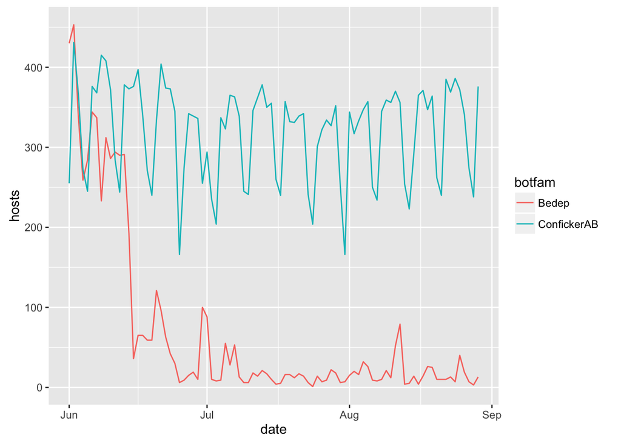

### pretty it up (1)

- Apply `theme_bw()` to the plot,
- Move the legend to the bottom (look at ?theme for ‘legend_position’)

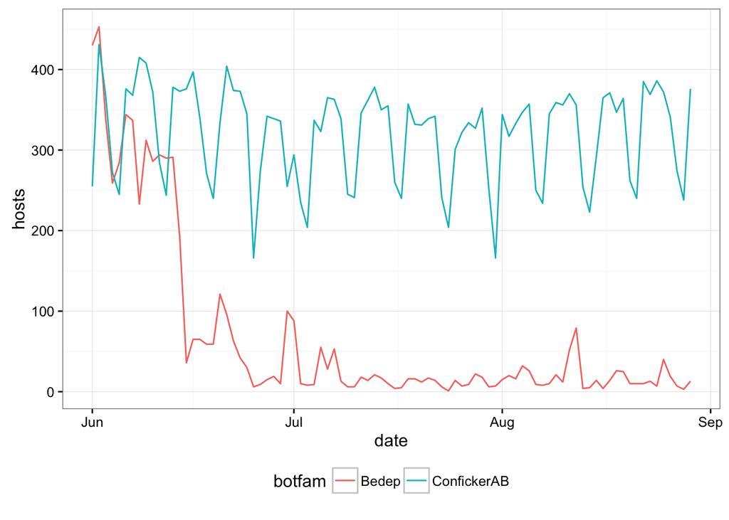

### make it bigger

you won’t see any difference unless you “Knit” the document, but the image size can be set in the {r} tag.

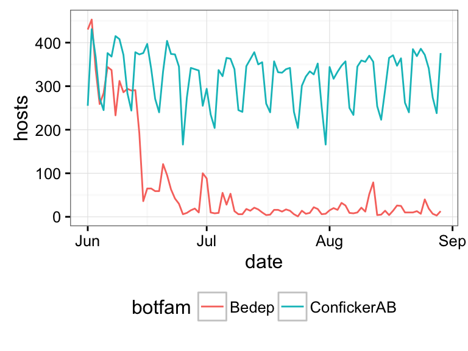

### Interactive

We won’t go to interactive graphics quite yet, but if you wanted to look for an interactive option, see [HTML Widgets](http://www.htmlwidgets.org/showcase_dygraphs.html). http://rstudio.github.io/dygraphs